# Multi-Class Classification Model for Steel Plates Faults Using R

David Lowe

June 26, 2018

Template Credit: Adapted from a template made available by Dr. Jason Brownlee of Machine Learning Mastery (http://machinelearningmastery.com/)

Dataset Used: Steel Plates Faults Dataset

Dataset ML Model: Multi-classification with numerical attributes

Dataset Reference: http://archive.ics.uci.edu/ml/datasets/steel+plates+faults

One potential source of performance benchmarks: https://www.kaggle.com/uciml/faulty-steel-plates

INTRODUCTION: This dataset comes from research by Semeion, Research Center of Sciences of Communication. The original aim of the research was to correctly classify the type of surface defects in stainless steel plates, with six types of possible defects (plus “other”). The Input vector was made up of 27 indicators that approximately the geometric shape of the defect and its outline. According to the research paper, Semeion was commissioned by the Centro Sviluppo Materiali (Italy) for this task and therefore it is not possible to provide details on the nature of the 27 indicators used as Input vectors or the types of the 6 classes of defects.

CONCLUSION: The baseline performance of the seven algorithms achieved an average accuracy of 69.69%. Three algorithms (Bagged CART, Random Forest, and Stochastic Gradient Boosting) achieved the top three accuracy scores after the first round of modeling. After a series of tuning trials, Stochastic Gradient Boosting turned in the top result using the training data. It achieved an average accuracy of 77.78%. Using the optimized tuning parameter available, the Stochastic Gradient Boosting algorithm processed the validation dataset with an accuracy of 77.20%, which was slightly below the accuracy from the training data. For this project, the Stochastic Gradient Boosting ensemble algorithm yielded consistently top-notch training and validation results, which warrant the additional processing required by the algorithm.

The purpose of this project is to analyze predictions using various machine learning algorithms and to document the steps using a template. Working through machine learning problems from end-to-end requires a structured modeling approach. Working problems through a project template can also encourage us to think about the problem more critically, to challenge our assumptions, and to get proficient at all parts of a modeling project.

The project aims to touch on the following areas:

1. Document a predictive modeling problem end-to-end.
2. Explore data cleaning and transformation options
3. Explore non-ensemble and ensemble algorithms for baseline model performance
4. Explore algorithm tuning techniques for improving model performance

Any predictive modeling machine learning project genrally can be broken down into about six major tasks:

1. Prepare Problem
2. Summarize Data
3. Prepare Data
4. Model and Evaluate Algorithms
5. Improve Accuracy or Results
6. Finalize Model and Present Results

## 1. Prepare Problem

### 1.a) Load libraries

```r
library(caret)
```

```r
library(corrplot)
```

### 1.b) Load dataset

```r
startTimeScript <- proc.time()
entireDataset <- read.csv("faults.csv", header= TRUE, stringsAsFactors = FALSE)

# First we need to reverse the one-hot-encoding effect for the class variable
entireDataset$targetVar <- 7
entireDataset$targetVar[entireDataset$Pastry==1] <- 1
entireDataset$targetVar[entireDataset$Z_Scratch==1] <- 2
entireDataset$targetVar[entireDataset$K_Scatch==1] <- 3
entireDataset$targetVar[entireDataset$Stains==1] <- 4
entireDataset$targetVar[entireDataset$Dirtiness==1] <- 5
entireDataset$targetVar[entireDataset$Bumps==1] <- 6
entireDataset$targetVar <- as.factor(entireDataset$targetVar)
entireDataset$Pastry <- NULL
entireDataset$Z_Scratch <- NULL
entireDataset$K_Scatch <- NULL
entireDataset$Stains <- NULL
entireDataset$Dirtiness <- NULL
entireDataset$Bumps <- NULL
entireDataset$Other_Faults <- NULL

# Use variable totCol to hold the number of columns in the dataframe
totCol <- ncol(entireDataset)
```

## 2. Summarize Data

To gain a better understanding of the data that we have on-hand, we will leverage a number of descriptive statistics and data visualization techniques. The plan is to use the results to consider new questions, review assumptions, and validate hypotheses that we can investigate later with specialized models.

### 2.a) Descriptive statistics

#### 2.a.i) Peek at the data itself.

```r
head(entireDataset)
```

```
##   X_Minimum X_Maximum Y_Minimum Y_Maximum Pixels_Areas X_Perimeter
## 1        42        50    270900    270944          267          17
## 2       645       651   2538079   2538108          108          10
## 3       829       835   1553913   1553931           71           8
## 4       853       860    369370    369415          176          13
## 5      1289      1306    498078    498335         2409          60
## 6       430       441    100250    100337          630          20
##   Y_Perimeter Sum_of_Luminosity Minimum_of_Luminosity
## 1          44             24220                    76
## 2          30             11397                    84
## 3          19              7972                    99
## 4          45             18996                    99
## 5         260            246930                    37
## 6          87             62357                    64
##   Maximum_of_Luminosity Length_of_Conveyer TypeOfSteel_A300
```

[output cut: 34 more lines]

#### 2.a.ii) Dimensions of the dataset.

```r
dim(entireDataset)
```

```
## [1] 1941   28
```

#### 2.a.iii) Types of the attributes.

```r
sapply(entireDataset, class)
```

```
##             X_Minimum             X_Maximum             Y_Minimum
##             "integer"             "integer"             "integer"
##             Y_Maximum          Pixels_Areas           X_Perimeter
##             "integer"             "integer"             "integer"
##           Y_Perimeter     Sum_of_Luminosity Minimum_of_Luminosity
##             "integer"             "integer"             "integer"
## Maximum_of_Luminosity    Length_of_Conveyer      TypeOfSteel_A300
##             "integer"             "integer"             "integer"
##      TypeOfSteel_A400 Steel_Plate_Thickness           Edges_Index
##             "integer"             "integer"             "numeric"
##           Empty_Index          Square_Index       Outside_X_Index
##             "numeric"             "numeric"             "numeric"
##         Edges_X_Index         Edges_Y_Index  Outside_Global_Index
##             "numeric"             "numeric"             "numeric"
##            LogOfAreas           Log_X_Index           Log_Y_Index
##             "numeric"             "numeric"             "numeric"
##     Orientation_Index      Luminosity_Index        SigmoidOfAreas
##             "numeric"             "numeric"             "numeric"
##             targetVar
##              "factor"
```

#### 2.a.iv) Statistical summary of all attributes.

```r
summary(entireDataset)
```

```
##    X_Minimum        X_Maximum      Y_Minimum          Y_Maximum
##  Min.   :   0.0   Min.   :   4   Min.   :    6712   Min.   :    6724
##  1st Qu.:  51.0   1st Qu.: 192   1st Qu.:  471253   1st Qu.:  471281
##  Median : 435.0   Median : 467   Median : 1204128   Median : 1204136
##  Mean   : 571.1   Mean   : 618   Mean   : 1650685   Mean   : 1650739
##  3rd Qu.:1053.0   3rd Qu.:1072   3rd Qu.: 2183073   3rd Qu.: 2183084
##  Max.   :1705.0   Max.   :1713   Max.   :12987661   Max.   :12987692
##
##   Pixels_Areas     X_Perimeter       Y_Perimeter       Sum_of_Luminosity
##  Min.   :     2   Min.   :    2.0   Min.   :    1.00   Min.   :     250
##  1st Qu.:    84   1st Qu.:   15.0   1st Qu.:   13.00   1st Qu.:    9522
##  Median :   174   Median :   26.0   Median :   25.00   Median :   19202
##  Mean   :  1894   Mean   :  111.9   Mean   :   82.97   Mean   :  206312
##  3rd Qu.:   822   3rd Qu.:   84.0   3rd Qu.:   83.00   3rd Qu.:   83011
##  Max.   :152655   Max.   :10449.0   Max.   :18152.00   Max.   :11591414
##
##  Minimum_of_Luminosity Maximum_of_Luminosity Length_of_Conveyer
##  Min.   :  0.00        Min.   : 37.0         Min.   :1227
##  1st Qu.: 63.00        1st Qu.:124.0         1st Qu.:1358
##  Median : 90.00        Median :127.0         Median :1364
##  Mean   : 84.55        Mean   :130.2         Mean   :1459
##  3rd Qu.:106.00        3rd Qu.:140.0         3rd Qu.:1650
##  Max.   :203.00        Max.   :253.0         Max.   :1794
##
##  TypeOfSteel_A300 TypeOfSteel_A400 Steel_Plate_Thickness  Edges_Index
##  Min.   :0.0000   Min.   :0.0000   Min.   : 40.00        Min.   :0.0000
##  1st Qu.:0.0000   1st Qu.:0.0000   1st Qu.: 40.00        1st Qu.:0.0604
##  Median :0.0000   Median :1.0000   Median : 70.00        Median :0.2273
##  Mean   :0.4003   Mean   :0.5997   Mean   : 78.74        Mean   :0.3317
##  3rd Qu.:1.0000   3rd Qu.:1.0000   3rd Qu.: 80.00        3rd Qu.:0.5738
##  Max.   :1.0000   Max.   :1.0000   Max.   :300.00        Max.   :0.9952
##
##   Empty_Index      Square_Index    Outside_X_Index   Edges_X_Index
##  Min.   :0.0000   Min.   :0.0083   Min.   :0.00150   Min.   :0.0144
##  1st Qu.:0.3158   1st Qu.:0.3613   1st Qu.:0.00660   1st Qu.:0.4118
##  Median :0.4121   Median :0.5556   Median :0.01010   Median :0.6364
##  Mean   :0.4142   Mean   :0.5708   Mean   :0.03336   Mean   :0.6105
##  3rd Qu.:0.5016   3rd Qu.:0.8182   3rd Qu.:0.02350   3rd Qu.:0.8000
##  Max.   :0.9439   Max.   :1.0000   Max.   :0.87590   Max.   :1.0000
##
```

[output cut: 9 more lines]

```
##  Min.   :0.000   Min.   :-0.99100   Min.   :-0.9989   Min.   :0.1190
##  1st Qu.:1.079   1st Qu.:-0.33330   1st Qu.:-0.1950   1st Qu.:0.2482
##  Median :1.322   Median : 0.09520   Median :-0.1330   Median :0.5063
##  Mean   :1.403   Mean   : 0.08329   Mean   :-0.1313   Mean   :0.5854
##  3rd Qu.:1.732   3rd Qu.: 0.51160   3rd Qu.:-0.0666   3rd Qu.:0.9998
##  Max.   :4.259   Max.   : 0.99170   Max.   : 0.6421   Max.   :1.0000
##
##  targetVar
##  1:158
##  2:190
##  3:391
##  4: 72
##  5: 55
##  6:402
##  7:673
```

#### 2.a.v) Summarize the levels of the class attribute.

```r
entireDataset_x <- entireDataset[,1:(totCol-1)]
entireDataset_y <- entireDataset[,totCol]
cbind(freq=table(entireDataset_y), percentage=prop.table(table(entireDataset_y))*100)
```

```
##   freq percentage
## 1  158   8.140134
## 2  190   9.788769
## 3  391  20.144256
## 4   72   3.709428
## 5   55   2.833591
## 6  402  20.710974
## 7  673  34.672849
```

#### 2.a.vi) Count missing values.

```r
sapply(entireDataset, function(x) sum(is.na(x)))
```

```
##             X_Minimum             X_Maximum             Y_Minimum
##                     0                     0                     0
##             Y_Maximum          Pixels_Areas           X_Perimeter
##                     0                     0                     0
##           Y_Perimeter     Sum_of_Luminosity Minimum_of_Luminosity
##                     0                     0                     0
## Maximum_of_Luminosity    Length_of_Conveyer      TypeOfSteel_A300
##                     0                     0                     0
##      TypeOfSteel_A400 Steel_Plate_Thickness           Edges_Index
##                     0                     0                     0
##           Empty_Index          Square_Index       Outside_X_Index
##                     0                     0                     0
##         Edges_X_Index         Edges_Y_Index  Outside_Global_Index
##                     0                     0                     0
##            LogOfAreas           Log_X_Index           Log_Y_Index
##                     0                     0                     0
##     Orientation_Index      Luminosity_Index        SigmoidOfAreas
##                     0                     0                     0
##             targetVar
##                     0
```

### 2.b) Data visualizations

#### 2.b.i) Univariate plots to better understand each attribute.

```r
# Set up a variable for the total number of attribute columns (totAttr)
totAttr <- totCol-1
# Set up the number of row and columns for visualization display. dispRow * dispCol should be >= totAttr
dispCol <- 7
if (totAttr%%dispCol == 0) {
dispRow <- totAttr%/%dispCol
} else {
dispRow <- (totAttr%/%dispCol) + 1
}
cat("Will attempt to create graphics grid (col x row): ", dispCol, ' by ', dispRow)
```

```
## Will attempt to create graphics grid (col x row):  7  by  4
```

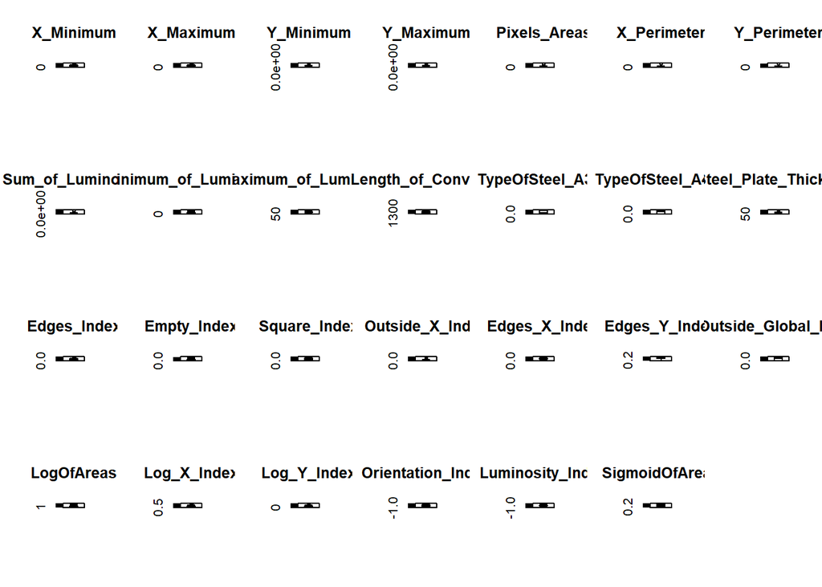

```r
# Boxplots for each attribute
par(mfrow=c(dispRow,dispCol))
for(i in 1:totAttr) {
    boxplot(entireDataset[,i], main=names(entireDataset)[i])
}
```

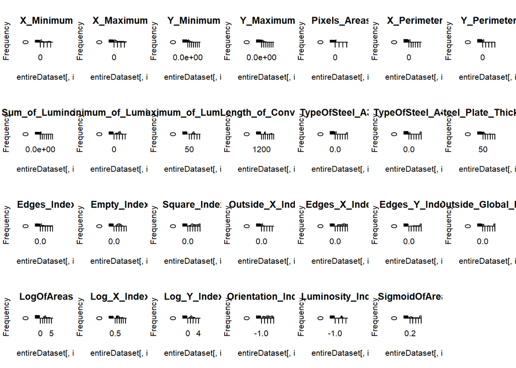

```r
# Histograms each attribute
par(mfrow=c(dispRow,dispCol))
for(i in 1:totAttr) {
    hist(entireDataset[,i], main=names(entireDataset)[i])
}
```

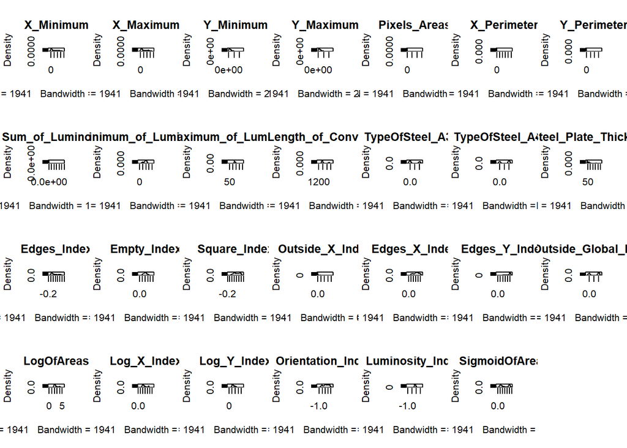

```r
# Density plot for each attribute
par(mfrow=c(dispRow,dispCol))
for(i in 1:totAttr) {
    plot(density(entireDataset[,i]), main=names(entireDataset)[i])
}
```

#### 2.b.ii) Multivariate plots to better understand the relationships between attributes

[figure not shown]

```r
# Scatterplot matrix colored by class
pairs(targetVar~., data=entireDataset, col=entireDataset$targetVar)
```

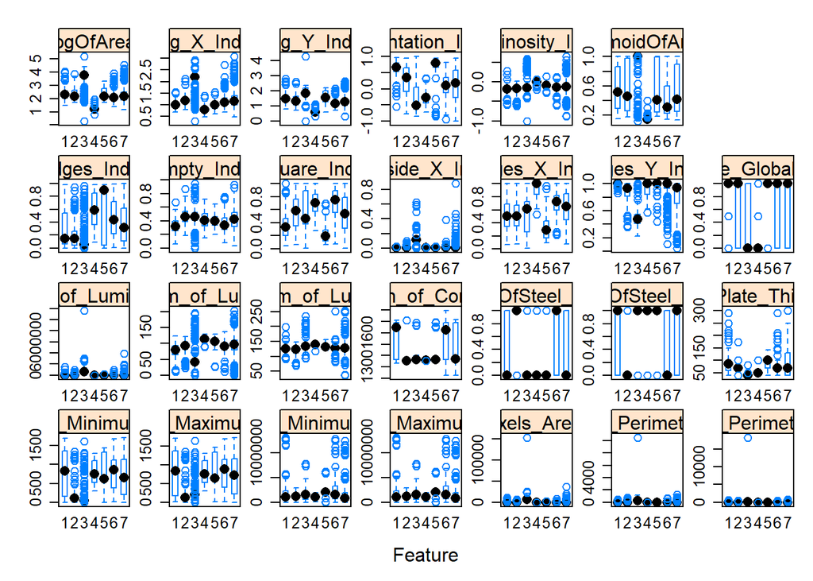

```r
# Box and whisker plots for each attribute by class
scales <- list(x=list(relation="free"), y=list(relation="free"))
featurePlot(x=entireDataset_x, y=entireDataset_y, plot="box", scales=scales)
```

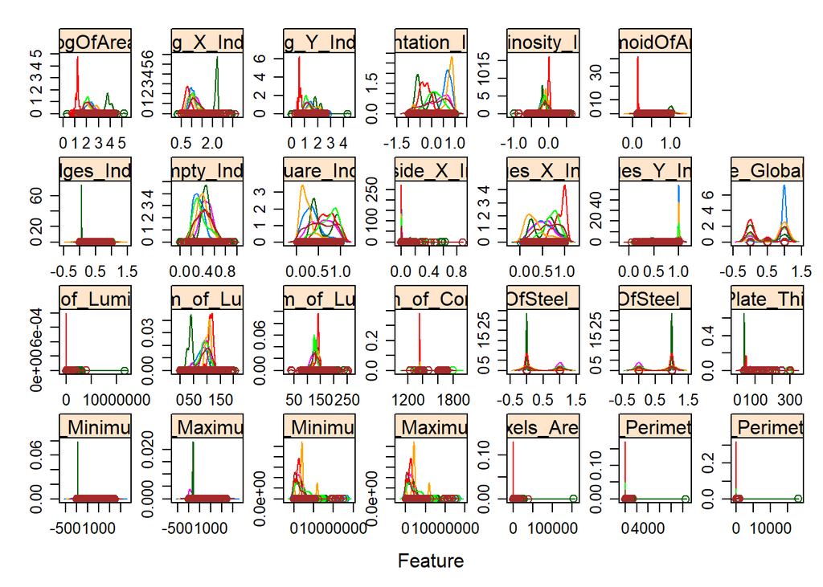

```r
# Density plots for each attribute by class value
featurePlot(x=entireDataset_x, y=entireDataset_y, plot="density", scales=scales)
```

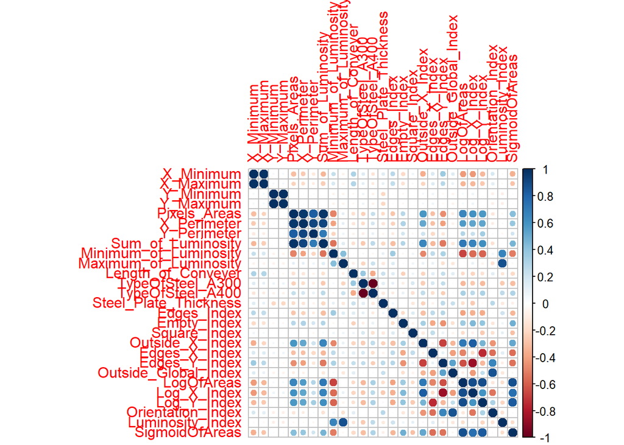

```r
# Correlation plot
correlations <- cor(entireDataset_x)
corrplot(correlations, method="circle")
```